# Auto-Stats

Arne John

2023-06-30

# 0: How to Read this Document

Currently, this is a static html page, representing the output (right side) of the JASP program. It is intended to become a pdf once the user hits the “stat-report” button, but for now it imitates the UI output.

Different types of text:

Regular text is the output found in the report, meant to be easily readable/understandable for the user.

SUPERSCRIPT DENOTES REQUIRED INPUTS or extra output not created. Additionally, [Choices] are denoted in brackets for now.

Red font is meant to show missing areas as reminders for me to improve on.

## Assumptions about this document

This document assumes the user is using one of the JASP library datasets. As the report is intended to be created for different types of tests, the selected JASP module will be listed here as well.

# 1. Data Selection

☐ Directed Reading Activities & Independent Samples t-Test (significant results)

☐ Kitchen Rolls & Independent Samples t-Test (not significant results)

☐ Moon and Aggression & Paired Samples t-Test

☐ Weight Gain & One Sample t-Test

☑ Student’s Sleep Data & Paired Samples t-Test

Student’s Sleep Data `sleep` is selected.

The IV is `group`, and the DV is `extra`.

### Introduction: What are you achieving with this test?

Dear user, You selected to conduct a Student’s t-test. This test checks whether the data follows a Student’s t-Distribution under the null hypothesis. It is often used to see whether the means of two sets of data are significantly different from one another.

First let’s take a look at the data as a raincloud plot:

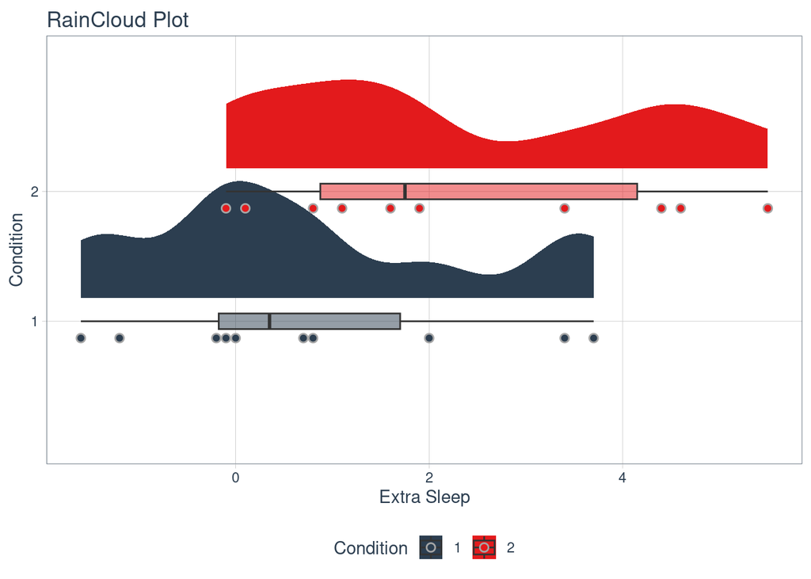

VISUAL CONFIRMATION OF EQUAL VARIANCE BETWEEN DATA SETS & OUTLIERS

Check for Model Misspecifications.

# Low Verbosity Level

### Descriptions (Assumptions about Outliers, Skewness, Homoscedasticity)

QUESTION: Should we only use Brown-Forsythe test? “The B-F test is less likely than the Levene test to incorrectly declare that the assumption of equal variances has been violated.” (https://www.statisticshowto.com/brown-forsythe-test/) INSERT/TODO: If quoted, this needs to go into references!

To test homogeneity of variance, Levene’s test was performed. The test did not show significance, meeting that the variances between the two groups is not significantly different. This means that you can safely conclude the results of the t-test.

The data set does not contain outliers.

The Shapiro-Wilk test is a statistical test that tests the null hypothesis that a sample came from a normally distributed population. The Shapiro-Wilk test showed that the data does not differ significantly from normal distribution. (That is good!)

ISSUE: This method of output requires there to be a object called ttest.

### Actual Test

#### Hypothesis Testing

# Medium Verbosity Level

Before you can conduct a Two Sample t-test, we first need to check for assumptions that need to be held in order for the test to be valid. The assumptions for a Two Sample t-test are as follows:

- The two sets of data have similar variance.
- There are no significant outliers in the data that could influence the results.
- Neither data set contains skewness in the distribution of results.

To test homogeneity of variance, Levene’s test was performed. The test did not show significance, meeting that the variances between the two groups is not significantly different. This means that you can safely conclude the results of the t-test.

It also assumes there to be no significant outliers that skew the results. To test this, both a Grubb’s test and a Dixon’s Q test were conducted. Both tests reported no significant effect of outliers, so you can safely report the results of the test.

## Actual Test

### Hypothesis Testing

#### Parameter Estimation

# High Verbosity Level

### What is Null-Hypothesis Significance Testing (NHST)?

Why are we doing this? It’s a comparison between means? But you could also just estimate parameters This procedure tests whether the group means are equal, but also the size of the difference assumption it’s not zero.

OLD VERSION: When researchers want to test a hypothesis, they usually [Is ‘usually’ reasonable to say? alt: In the majority of cases?] test more than one hypothesis and see how well the data is explained by each one. In classical/frequentist statistical hypothesis testing, this is often done by having one hypothesis assume that the data, which is following some form of distribution, is influenced by a certain parameter, while the other assumes this parameter to have no effect, i.e. the data’s variation is only influenced by its distribution. This “other” distribution is conventionally called the null hypothesis $\(H_0)$ , while the hypothesis with the added parameter is referred to as the statistical/alternative hypothesis $\(H_1)$.

NEW VERSION: When researchers want to test whether some property or parameter has an effect on the distribution of observed data, they conduct a null hypothesis test. In this case, the null hypothesis assumes that the parameter influencing the distribution has no effect, i.e. is equal to zero. In contrast, the alternative/statistical hypothesis calculates the size of the effect on the distribution.

Statistical significance is asserted via the p value. This value calculated by the probability of obtaining a parameter that is at least as extreme as the observed parameter, assuming the null hypothesis to be correct/true. In other words, were one to repeat this experiment and collect data each time, the chance of getting a test result that is as high or higher as the observed result would only occur in p value*100 percent of the time. Significance is assumed if the p value falls below some previously asserted threshold value, usually set to 0.05, also known as the alpha level.

Is the word parameter here correct? Or do I need to say test result?

### Descriptions / Assumptions

Before you can conduct a Two Sample t-test, we first need to check for assumptions that need to be held in order for the test to be valid. The assumptions for a Two Sample t-test are as follows:

- The two populations in the data have similar variance.
- There are no significant outliers in the data that could influence the results.
- Neither data set contains skewness in their distribution.

Should independence be discussed? Can we test for independence in a meaningful way, or is it just meant to be “thought-provoking?”

#### Equality of Variance / Homoscedasity

A t-test (and the other types of ANOVAs as well as regressions) assumes that although different samples can come from populations with different means, they have the same variance. Were the variances different, i.e. would the different populations have differing distributions, then you are in a sense comparing apples and oranges. While there can be mitigating factors, such as fixed effects and similar sample sizes, different variances indicate that a t-test is an invalid method to compare these populations.

To test homogeneity of variance, Levene’s test was performed. The test did not show significance, meeting that the variances between the two groups is not significantly different. This means that you can safely conclude the results of the t-test.

#### Outliers

Do we want a paragraph on outliers, given that the raincloud plot is above?

It also assumes there to be no significant outliers that skew the results. To test this, both a Grubb’s test and a Dixon’s Q test were conducted. Both tests reported no significant effect of outliers, so you can safely report the results of the test.

#### Skewness

“Although paired t test are relatively robust to skewness, you could either do a transformation (e.g. log-transform), or consider to compare the results to a rank-based test”

#### Normality test (Shapiro-Wilk)

The Shapiro-Wilk test is a statistical test that tests the null hypothesis that a sample came from a normally distributed population. The Shapiro-Wilk test showed that the data does not differ significantly from normal distribution.

INSERT/TODO: If the user does a one-way or one-sample t-test, include the following for normality assumptions: One common misconception when doing hypothesis testing with an ANOVA is that the normality assumption must be met for all groups. However, the one-way ANOVA is considered a robust test against the normality assumption, meaning that it tolerates violations to its normality assumption rather well1.

### Actual Test

Datasets: Is it possible to have a dataset on which one can test all types of statistical tests? Can you reasonably run an independent and paired t test on the same dataset?

INSERT/TODO Still needs updating to only compare either independent or paired tests. For a discussion on choosing between the t-test and nonparametric alternatives, see Lumley, et al. (2002).

Don’t compare paired vs independent t tests.

Have the user choose whether the alternative is two sided, less, or greater, for purpose of demonstration it’s less.

### Hypothesis Testing

##### Misconceptions on Hypothesis Testing

One common misconception about Hypothesis Testing is that after computing an appropriate decision statistic under NHST (Null Hypothesis Significance Testing), you determined whether or not this provides sufficient evidence to reject the assumption that the Null Hypothesis is true. However, this does not mean that we have proven which hypothesis is true. If there are multiple hypotheses as to why there could be a difference between the populations, consider doing an ANOVA, where you can test between more than two hypotheses.

### Limitations of NHST

There exist several criticisms to this method to determine the significance of an effect.

- it never actually tests the statistical hypothesis.
- The threshold of 0.05 is arbitrary
- due to its method, interpretations are often incorrect as they forget/falsely assert the meaning of the probability being dependent on the null hypothesis being true
- requires blindness of the researchers on the data to avoid bias.

# Sources/References

Fisher, R (1955). “Statistical Methods and Scientific Induction”. Journal of the Royal Statistical Society, Series B. 17 (1): 69–78.

Lumley, T., Diehr, P.; Emerson, S., Chen, L. (2002). “The Importance of the Normality Assumption in Large Public Health Data Sets”. Annual Review of Public Health. 23 (1): 151–169. doi:10.1146/annurev.publhealth.23.100901.140546. ISSN 0163-7525. PMID 11910059.

Neyman, J, Pearson, E. S. (1933). “On the Problem of the most Efficient Tests of Statistical Hypotheses”. Philosophical Transactions of the Royal Society A. 231 (694–706): 289–337.

## Tests

Raincloud Plots Paper Kruskal-Wallis test

Mann-Whitney Non-Parametric Test / Wilcoxon Rank Sum David F. Bauer (1972). Constructing confidence sets using rank statistics. Journal of the American Statistical Association 67, 687–690. doi: 10.1080/01621459.1972.10481279.

Myles Hollander and Douglas A. Wolfe (1973). Nonparametric Statistical Methods. New York: John Wiley & Sons. Pages 27–33 (one-sample), 68–75 (two-sample). Or second edition (1999).

Shapiro-Wilk Normality Test Patrick Royston (1982). An extension of Shapiro and Wilk’s WW test for normality to large samples. Applied Statistics, 31, 115–124. doi:10.2307/2347973.

Levene’s test Fox, J. and Weisberg, S. (2019) An R Companion to Applied Regression, Third Edition, Sage.

Student’s t-test “Student” William Sealy Gosset (1908). “The probable error of a mean” (PDF). Biometrika. 6 (1): 1–25. doi:10.1093/biomet/6.1.1. hdl:10338.dmlcz/143545.

Welch’s t-test Welch, B. L. (1947). “The generalization of”Student’s” problem when several different population variances are involved”. Biometrika. 34 (1–2): 28–35. doi:10.1093/biomet/34.1-2.28